# Pref. attachment & fat-tailed distributions

Jackson Zhou (2023-11-02)

# Motivation

## Power-law degree distributions

- The degree distributions of real-world networks are observed to follow a power law, with $p(k)\propto k^{-\gamma}$ for some $\gamma>0$. This is not captured by simpler models such as the Erdős-Rényi model.
- The Barabási-Albert (BA) model aims to model this power law by having new nodes preferentially attach to existing nodes with higher degrees.

## Problem statement

The BA model generates power-law degree distributions with $\gamma=3$, while typically $\gamma\in(2,3)$ for real-world networks.

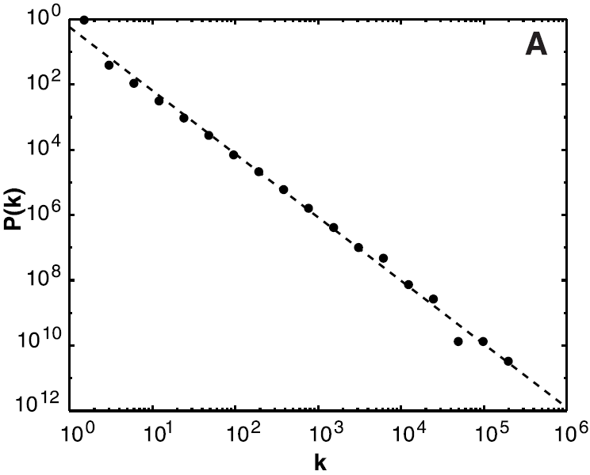

Figure 1: Log-log plot of the degree distribution of websites from a crawl in Spring 1997 (Adamic and Huberman, 2000). The dashed line has negative slope $\gamma=1.94$.

# Key question

**How can one modify the BA model to create power-law degree distributions with $\gamma\neq3$?**

# Main results

## The growing random network model

Consider Krapivsky et al. (2000), who characterise a generalisation of the BA model, known as the growing random network (GN) model.

**GN model definition**

The GN model with connection kernel $\pi:\mathbb{N}\to\mathbb{R}_{\geq0}$ and initial graph $G_0$ generates a sequence of graphs $G_1,G_2,\cdots$, where given $G_t$, $G_{t+1}$ is constructed by:

1. Adding a new node to $V(G_t)$.
2. Connecting the new node via an edge to an element of $V(G_t)$, such that node $i$ is connected to with probability proportional to $\pi(d_i)$.

## The connection kernel

Krapivsky et al. (2000) focus on connection kernels of the form $\pi(k)=k^\alpha$, for $\alpha\geq 0$. Let $\mathcal{N}_{k,t}$ be the expected number of $k$-degree nodes at time $t$. The authors derive the rate equation
$$\frac{d\mathcal{N}_{k,t}}{dt}=\frac{1}{M_{\alpha,t}}\left[(k-1)^\alpha \mathcal{N}_{k-1,t}-k^\alpha \mathcal{N}_{k,t}\right]+\delta_{k1},$$
where $M_{\alpha,t}=\sum_{j=1}^\infty j^\alpha \mathcal{N}_{j,t}$ is a normalising constant and $\delta_{k1}=\mathbf{1}_{k=1}$. This is used to derive the degree distribution of the GN model in three regimes.

## Linear regime

In this scenario, $\alpha=1$ (the BA model). It is shown that
$$\lim_{t\to\infty}p_t(k)=\frac{4}{k(k+1)(k+2)}\sim 4k^{-3},$$
which is the same result from the lectures. Additionally, when $\pi(1)=1$ and $\pi(k)=Ck$ for $k\geq2$ and $C>0$,
$$\lim_{t\to\infty}p_t(k)\sim k^{-(3+\sqrt{1+8/C})/2}.$$

# Numerical experiments

## Linear regime: degree distribution

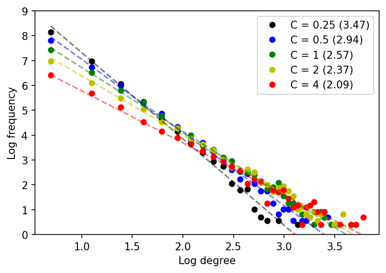

Figure 2: Log-log plot of the degree distribution of linear GN models with $n=10000$. Each point represents an average over four repetitions. The dotted lines represent fitted lines, and the $\gamma$ estimates are in parentheses.

## Linear regime: estimated gamma

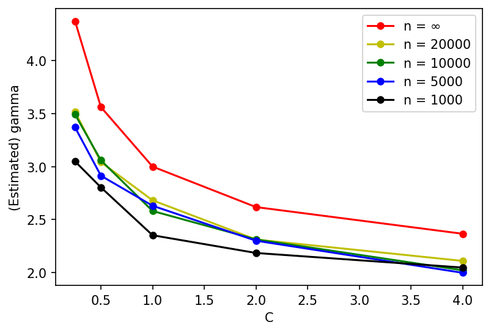

Figure 3: $\gamma$ vs. $C$ for the linear GN model across a range of $n$ values. Each point represents an average over four repetitions. The red curve represents the theoretical relationship.

# Questions?

Slides made with [Quarto reveal.js](https://quarto.org/docs/presentations/revealjs/).